# Reproducible Research: Peer Assessment 1

Germán Fajardo G

may 3 of 2018

## Introduction

It is now possible to collect a large amount of data about personal movement using activity monitoring devices such as a [Fitbit](http://www.fitbit.com), [Nike Fuelband](http://www.nike.com/us/en_us/c/nikeplus-fuelband), or [Jawbone Up](https://jawbone.com/up). These type of devices are part of the “quantified self” movement – a group of enthusiasts who take measurements about themselves regularly to improve their health, to find patterns in their behavior, or because they are tech geeks. But these data remain under-utilized both because the raw data are hard to obtain and there is a lack of statistical methods and software for processing and interpreting the data.

This assignment makes use of data from a personal activity monitoring device. This device collects data at 5 minute intervals through out the day. The data consists of two months of data from an anonymous individual collected during the months of October and November, 2012 and include the number of steps taken in 5 minute intervals each day.

# Loading and preprocessing the data

## Load the data (i.e. read.csv())

```r
##Set default directory
setwd("C:/Git/RepData_PeerAssessment1")

##Extract files from file
unzip(zipfile="activity.zip")

##Read the csv File
Activity <- read.csv("activity.csv")

## Show the columns ad its first values
str(Activity)
```

```
## 'data.frame':    17568 obs. of  3 variables:
##  $ steps   : int  NA NA NA NA NA NA NA NA NA NA ...
##  $ date    : Factor w/ 61 levels "2012-10-01","2012-10-02",..: 1 1 1 1 1 1 1 1 1 1 ...
##  $ interval: int  0 5 10 15 20 25 30 35 40 45 ...
```

## Process/transform the data (if necessary) into a format suitable for your analysis

## Omit na Values from values

```r
Data <- na.omit(Activity)
```

## Show first six rows without NA

```r
head(Data, 6)
```

```
##     steps       date interval
## 289     0 2012-10-02        0
## 290     0 2012-10-02        5
## 291     0 2012-10-02       10
## 292     0 2012-10-02       15
## 293     0 2012-10-02       20
## 294     0 2012-10-02       25
```

# What is mean total number of steps taken per day?

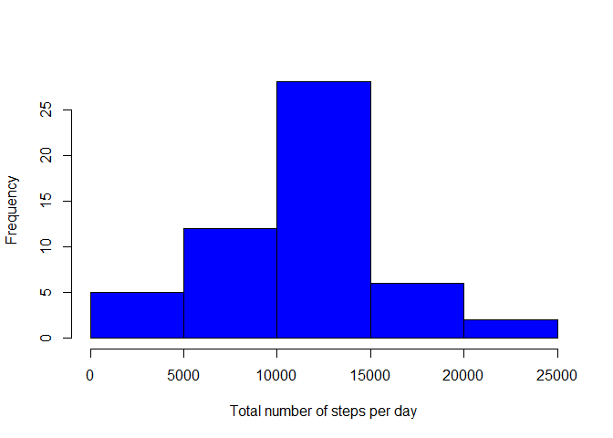

```r
StepPerDays <- aggregate(steps ~ date, data = Data, FUN = sum)
hist(StepPerDays$steps, xlab="Total number of steps per day", main=NULL, col="blue")
```

```r
head(StepPerDays, 6)
```

```
##         date steps
## 1 2012-10-02   126
## 2 2012-10-03 11352
## 3 2012-10-04 12116
## 4 2012-10-05 13294
## 5 2012-10-06 15420
## 6 2012-10-07 11015
```

# What is the average daily activity pattern?

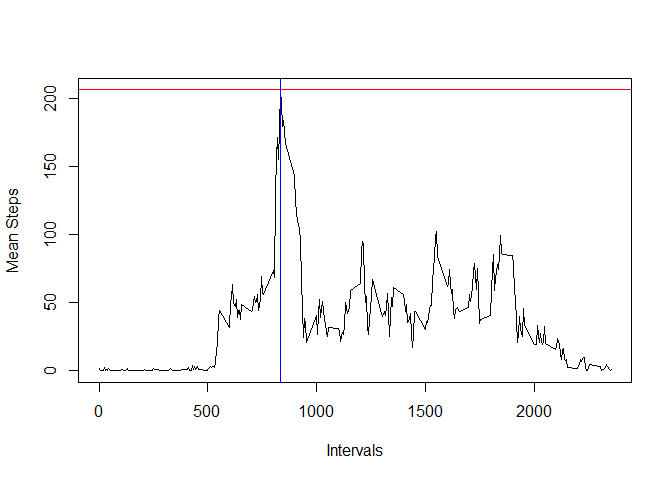

```r
StepPerInterval <- aggregate(steps ~ interval, data = Activity, FUN = function(x) { mean(x, na.rm = TRUE) })

plot2 <- plot(StepPerInterval$interval, StepPerInterval$steps, type="l", xlab="Intervals", ylab="Mean Steps")

max.StepPerInterval = max(StepPerInterval$steps)
max.Int = StepPerInterval[StepPerInterval$steps==max(max.StepPerInterval),1]

abline(h=max.StepPerInterval, col = c("red"))
abline(v=max.Int, col = c("blue"))
```

## Calculate mean of Step of days

```r
meanSteps<-mean(StepPerDays$steps)
meanSteps
```

```
## [1] 10766.19
```

## Calculate median

```r
medianSteps<-median(StepPerDays$steps)
medianSteps
```

```
## [1] 10765
```

```r
MaxSteps = max(StepPerInterval$steps)
MaxSteps
```

```
## [1] 206.1698
```